# To edit a text cell

double click on it. You can enter text in LaTeX code as shown here (if you double click) $$\mbox{LaTeX is }\sqrt{1+\tan^2(c)}.$$

# Some resources for using Python to study Matrices:

- [Python numerical methods](https://pythonnumericalmethods.berkeley.edu/notebooks/Index.html) online text, Chapters 1-6
- [Python for beginners](https://https://www.youtube.com/watch?v=kqtD5dpn9C8) YouTube video
- LearnPython.org interactive website
- I've included some useful commands at the very end of this worksheet as well.

# A couple quick notes:

- Make use of the math department and Quad center tutors, as well as my office hours and the discord channel, if you are new to coding
- Lists in python are indexed starting at 0, so if you have list

```
a=[1,2,5,7]
```

and you wanted to access the third element, you would type

```
a[2]
```

and python would return

```
5
```

# Instructions

In this assignment you will write a Python program to find a cubic spline through any four points $(x_0, y_0), (x_1, y_1), (x_2, y_2),$ and $(x_3, y_3)$ in the plane.

**Part I - due Friday 2/2**

1. Start by reading [Python Numerical Methods section 17.3](https://pythonnumericalmethods.berkeley.edu/notebooks/chapter17.03-Cubic-Spline-Interpolation.html) to learn about Cubic Splines. This reading includes python commands you will likely want to incorporate into your code. Make sure you understand any commands used.
2. The cubic spline between 4 points will consist of 3 cubic functions, each of the form $S_i=a_ix^3+b_ix^2+c_ix+d_i$. Thus, your function needs to find the 12 uknown parameter values $a_1, b_1, \ldots, c_3, d_3$ from the user inputted 4 points $(x_0, y_0), (x_1, y_1), (x_2, y_2),$ and $(x_3, y_3)$. In the text cell below, or on a seperate peice of paper, write down
- the 3 equations corresponding to the requirements $S_i(x_i)=y_i$
- the 3 equations corresponding to the requirements $S_i(x_{i+1})=y_{i+1}$
- the 2 equations corresponding to the requirement $S_i'(x_{i+1})=S'_{i+1}(x_{i+1})$
- the 2 equations corresponding to the requirement $S_i''(x_{i+1})=S''_{i+1}(x_{i+1})$
- and the 2 equations corresponding to the requirement $S_0''(x_0)=0$ and $S''_2(x_3)=0$

$$a_{1}x_{1}^{3}+b_{1}x_{1}^{2}+c_{1}x_{1}+d_{1}=y_{1}$$ $$a_{2}x_{2}^{3}+b_{2}x_{2}^{2}+c_{2}x_{2}+d_{2}=y_{2}$$ $$a_{3}x_{3}^{3}+b_{3}x_{3}^{2}+c_{3}x_{3}+d_{3}=y_{3}$$ $$a_{1}x_{2}^{3}+b_{1}x_{2}^{2}+c_{1}x_{2}+d_{1}=y_{2}$$ $$a_{2}x_{3}^{3}+b_{2}x_{3}^{2}+c_{2}x_{3}+d_{2}=y_{3}$$ $$a_{3}x_{4}^{3}+b_{3}x_{4}^{2}+c_{3}x_{4}+d_{3}=y_{4}$$ $$3a_{1}x_{2}^{2}+2b_{1}x_{2}+c_{1}-3a_{2}x_{2}^{2}-2b_{2}x_{2}-c_{2}=0$$ $$3a_{2}x_{3}^{2}+2b_{2}x_{3}+c_{2}-3a_{3}x_{3}^{2}-2b_{3}x_{3}-c_{3}=0$$ $$6a_{1}x_{2}+2b_{1}-6a_{2}x_{2}-2b_{2}=0$$ $$6a_{2}x_{3}+2b_{2}-6a_{3}x_{3}-2b_{3}=0$$ $$6a_{1}x_{1}+2b_{1}=0$$ $$6a_{3}x_{4}+2b_{3}=0$$

**Enter your equations here, upload a photo of them, or turn them in on a seperate piece of paper.**

3. Using the equations found in part 2, find a $12\times 12$ matrix $A$ such that

\begin{align} A \begin{bmatrix} a_0\\ b_0\\ c_0\\ d_0\\ a_1\\ b_1\\ \vdots \\ c_2\\ d_2 \end{bmatrix}= \begin{bmatrix} y_0\\ y_1\\ y_2\\ y_1\\ y_2\\ y_3\\ 0\\ \vdots \\ 0 \end{bmatrix}. \end{align}

Arrange the rows of your matrix so that they correspond with the equations described in part 2 in the order given in part 2. The entries of your matrix should be in terms of powers of $x_i$ and constant multiples of powers of $x_i$.

**Enter your matrix here or turn it in on a seperate piece of paper.**

**Part II - due Monday 2/5** 4. Using the formula for the matrix $A$ you found above, modify the code below to create a function with returns the cubic spline through four points.

```python
import sympy
import numpy as np
from sympy import *
from numpy.polynomial import Polynomial


# def allows you to create functions and subroutines in Python
def MyCubicSpline(x,y):
  #Construct your matrix A.



  A= np.array([[(x[0])**3, (x[0])**2, x[0], 1, 0, 0, 0, 0, 0, 0, 0, 0], [0, 0, 0, 0, (x[1])**3, (x[1])**2, x[1], 1, 0, 0, 0, 0], [0, 0, 0, 0, 0, 0, 0, 0, (x[2])**3, (x[2])**2, x[2], 1], [(x[1])**3, (x[1])**2, x[1], 1, 0, 0, 0, 0, 0, 0, 0, 0], [0, 0, 0, 0, (x[2])**3, (x[2])**2, x[2], 1, 0, 0, 0, 0], [0, 0, 0, 0, 0, 0, 0, 0, (x[3])**3, (x[3])**2, x[3], 1], [3*(x[1])**2, 2*(x[1]), 1, 0, -3*(x[1])**2, -2*(x[1]), -1, 0, 0, 0, 0, 0], [0, 0, 0, 0, 3*(x[2])**2, 2*(x[2]), 1, 0, -3*(x[2])**2, -2*(x[2]), -1, 0], [6*(x[1]), 2, 0, 0, -6*(x[1]), -2, 0, 0, 0, 0, 0, 0], [0, 0, 0, 0, 6*(x[2]), 2, 0, 0, -6*(x[2]), -2, 0, 0], [6*(x[0]), 2, 0, 0, 0, 0, 0, 0, 0, 0, 0, 0], [0, 0, 0, 0, 0, 0, 0, 0, 6*(x[3]), 2, 0, 0]])

  matrix_B = np.array([[y[0]], [y[1]], [y[2]], [y[1]], [y[2]], [y[3]], [0], [0], [0], [0], [0], [0]])


  #matrix_B = matrix_B[:, np.newaxis]


  matrix_Ainv = np.linalg.inv(A) #Minv is the inverse of the matrix M
  c = np.dot(matrix_Ainv, matrix_B)  # c is the matrix-vector product (Minv)v




  # Use sympy.rref() method
  # print(matrix_A.rref()) #M.rref() returns both the RREF of M and a list of the columns containing pivot 1's
  # M_rref=matrix_A.rref()[0]    # Here I am setting M_rref equal to just the RREF of M, and ignoring the vector of pivot 1 locations.
  # print("The Row echelon form of matrix M and the pivot columns : {}".format(matrix_A_rref))

  #Solve for the coefficent values, and replace the values I have below
  #See the cell at the bottom of this worksheet for some commands that might help you.
  a1=c[0][0]
  b1=c[1][0]
  c1=c[2][0]
  d1=c[3][0]
  a2=c[4][0]
  b2=c[5][0]
  c2=c[6][0]
  d2=c[7][0]
  a3=c[8][0]
  b3=c[9][0]
  c3=c[10][0]
  d3=c[11][0]

  #numpy has a polynomial builder.  Be careful of the order of the coefficients here!
  S1=Polynomial([d1, c1, b1, a1])
  S2=Polynomial([d2, c2, b2, a2])
  S3=Polynomial([d3, c3, b3, a3])

  # S1=Polynomial([1, 1, 1, 1])
  # S2=Polynomial([1, 1, 1, 1])
  # S3=Polynomial([1, 1, 1, 1])
  print(A)
  return (S1, S2, S3)
```

5. Modify the code below to test your fuction on the points $(1, 2), (3, 4), (5, −1),$ and $(7, 0)$, and display the resulting graph.

```
[[  1   1   1   1   0   0   0   0   0   0   0   0]
 [  0   0   0   0  27   9   3   1   0   0   0   0]
 [  0   0   0   0   0   0   0   0 125  25   5   1]
 [ 27   9   3   1   0   0   0   0   0   0   0   0]
 [  0   0   0   0 125  25   5   1   0   0   0   0]
 [  0   0   0   0   0   0   0   0 343  49   7   1]
 [ 27   6   1   0 -27  -6  -1   0   0   0   0   0]
 [  0   0   0   0  75  10   1   0 -75 -10  -1   0]
 [ 18   2   0   0 -18  -2   0   0   0   0   0   0]
 [  0   0   0   0  30   2   0   0 -30  -2   0   0]
 [  6   2   0   0   0   0   0   0   0   0   0   0]
 [  0   0   0   0   0   0   0   0  42   2   0   0]]
0.14999999999999947 + 1.283333333333333·x¹ + 0.8500000000000002·x² -
0.28333333333333327·x³
-22.12500000000002 + 23.558333333333355·x¹ - 6.575000000000009·x² +
0.5416666666666676·x³
77.87499999999969 - 36.441666666666514·x¹ + 5.424999999999978·x² -
0.25833333333333214·x³
```

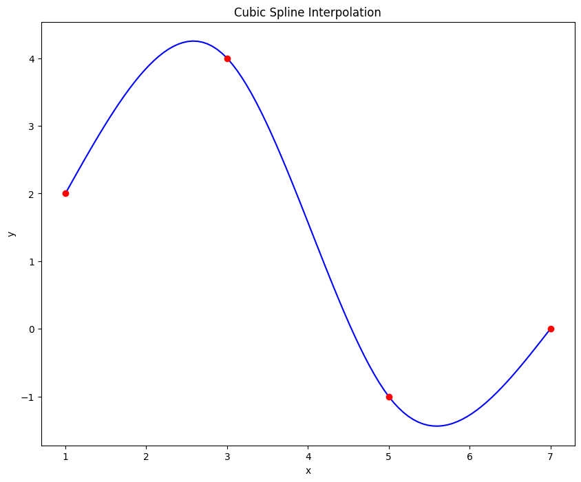

```python
import matplotlib.pyplot as plt

xp=[1,3,5,7]
yp=[2,4,-1,0]
(S1, S2, S3)=MyCubicSpline(xp,yp)
print(S1)
print(S2)
print(S3)


x = np.linspace(xp[0], xp[3], 100)
#piecewise is a numpy function for defining a piecewise function. lambda allows us to pass in x as a variable into the pieces of our function.
y=np.piecewise(x, [((x >= xp[0]) & (x < xp[1])), ((x >= xp[1]) & (x < xp[2])), ((x >= xp[2]) & (x <= xp[3]))], [lambda x : S1(x), lambda x : S2(x), lambda x : S3(x)])
plt.figure(figsize = (10,8))
plt.plot(x, y, 'b')
plt.plot(xp, yp, 'ro')
plt.title('Cubic Spline Interpolation')
plt.xlabel('x')
plt.ylabel('y')
plt.show()
```

6. Modify your code from parts 4 and 5 in cells below to create a function that returns the modified cubic spline - one that makes the first derivative of the functions at the first and last points 0, rather than the second derivatives. Try this new program on the points above. Show the output of both forms of the cubic spline and write a sentence about the qualitative difference between the two in the text cell below the code cell.

```python
import sympy
import numpy as np
from sympy import *
from numpy.polynomial import Polynomial


# def allows you to create functions and subroutines in Python
def MyCubicSpline(x,y):
  #Construct your matrix A.



  A= np.array([[(x[0])**3, (x[0])**2, x[0], 1, 0, 0, 0, 0, 0, 0, 0, 0], [0, 0, 0, 0, (x[1])**3, (x[1])**2, x[1], 1, 0, 0, 0, 0], [0, 0, 0, 0, 0, 0, 0, 0, (x[2])**3, (x[2])**2, x[2], 1], [(x[1])**3, (x[1])**2, x[1], 1, 0, 0, 0, 0, 0, 0, 0, 0], [0, 0, 0, 0, (x[2])**3, (x[2])**2, x[2], 1, 0, 0, 0, 0], [0, 0, 0, 0, 0, 0, 0, 0, (x[3])**3, (x[3])**2, x[3], 1], [3*(x[1])**2, 2*(x[1]), 1, 0, -3*(x[1])**2, -2*(x[1]), -1, 0, 0, 0, 0, 0], [0, 0, 0, 0, 3*(x[2])**2, 2*(x[2]), 1, 0, -3*(x[2])**2, -2*(x[2]), -1, 0], [6*(x[1]), 2, 0, 0, -6*(x[1]), -2, 0, 0, 0, 0, 0, 0], [0, 0, 0, 0, 6*(x[2]), 2, 0, 0, -6*(x[2]), -2, 0, 0], [3*x[0]**2, 2*x[0], 1, 0, 0, 0, 0, 0, 0, 0, 0, 0], [0, 0, 0, 0, 0, 0, 0, 0, 3*(x[3]**2), 2*x[3], 1, 0]])

  matrix_B = np.array([[y[0]], [y[1]], [y[2]], [y[1]], [y[2]], [y[3]], [0], [0], [0], [0], [0], [0]])


  #matrix_B = matrix_B[:, np.newaxis]


  matrix_Ainv = np.linalg.inv(A) #Minv is the inverse of the matrix M
  c = np.dot(matrix_Ainv, matrix_B)  # c is the matrix-vector product (Minv)v




  # Use sympy.rref() method
  # print(matrix_A.rref()) #M.rref() returns both the RREF of M and a list of the columns containing pivot 1's
  # M_rref=matrix_A.rref()[0]    # Here I am setting M_rref equal to just the RREF of M, and ignoring the vector of pivot 1 locations.
  # print("The Row echelon form of matrix M and the pivot columns : {}".format(matrix_A_rref))

  #Solve for the coefficent values, and replace the values I have below
  #See the cell at the bottom of this worksheet for some commands that might help you.
  a1=c[0][0]
  b1=c[1][0]
  c1=c[2][0]
  d1=c[3][0]
  a2=c[4][0]
  b2=c[5][0]
  c2=c[6][0]
  d2=c[7][0]
  a3=c[8][0]
  b3=c[9][0]
  c3=c[10][0]
  d3=c[11][0]

  #numpy has a polynomial builder.  Be careful of the order of the coefficients here!
  S1=Polynomial([d1, c1, b1, a1])
  S2=Polynomial([d2, c2, b2, a2])
  S3=Polynomial([d3, c3, b3, a3])

  # S1=Polynomial([1, 1, 1, 1])
  # S2=Polynomial([1, 1, 1, 1])
  # S3=Polynomial([1, 1, 1, 1])
  print(A)
  return (S1, S2, S3)
```

```
[[  1   1   1   1   0   0   0   0   0   0   0   0]
 [  0   0   0   0  27   9   3   1   0   0   0   0]
 [  0   0   0   0   0   0   0   0 125  25   5   1]
 [ 27   9   3   1   0   0   0   0   0   0   0   0]
 [  0   0   0   0 125  25   5   1   0   0   0   0]
 [  0   0   0   0   0   0   0   0 343  49   7   1]
 [ 27   6   1   0 -27  -6  -1   0   0   0   0   0]
 [  0   0   0   0  75  10   1   0 -75 -10  -1   0]
 [ 18   2   0   0 -18  -2   0   0   0   0   0   0]
 [  0   0   0   0  30   2   0   0 -30  -2   0   0]
 [  3   2   1   0   0   0   0   0   0   0   0   0]
 [  0   0   0   0   0   0   0   0 147  14   1   0]]
4.599999999999996 - 5.899999999999991·x¹ + 3.9999999999999947·x² -
0.6999999999999988·x³
-33.87499999999997 + 32.574999999999974·x¹ - 8.824999999999998·x² +
0.7250000000000001·x³
128.62499999999912 - 64.92499999999953·x¹ + 10.674999999999917·x² -
0.5749999999999951·x³
```

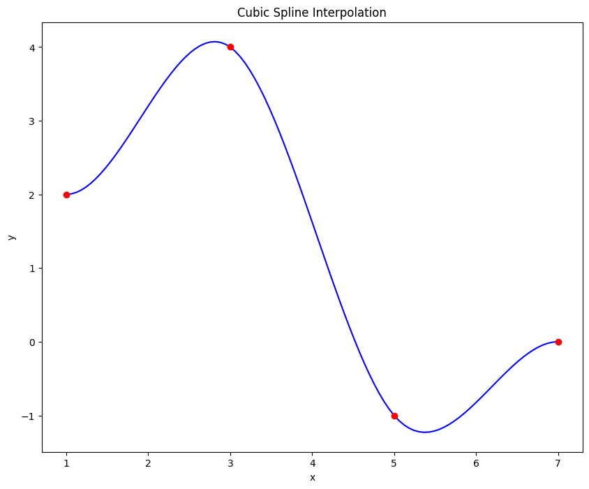

```python
import matplotlib.pyplot as plt

xp=[1,3,5,7]
yp=[2,4,-1,0]
(S1, S2, S3)=MyCubicSpline(xp,yp)
print(S1)
print(S2)
print(S3)


x = np.linspace(xp[0], xp[3], 100)
#piecewise is a numpy function for defining a piecewise function. lambda allows us to pass in x as a variable into the pieces of our function.
y=np.piecewise(x, [((x >= xp[0]) & (x < xp[1])), ((x >= xp[1]) & (x < xp[2])), ((x >= xp[2]) & (x <= xp[3]))], [lambda x : S1(x), lambda x : S2(x), lambda x : S3(x)])
plt.figure(figsize = (10,8))
plt.plot(x, y, 'b')
plt.plot(xp, yp, 'ro')
plt.title('Cubic Spline Interpolation')
plt.xlabel('x')
plt.ylabel('y')
plt.show()
```

Looking at our 2 cubic splines it looks like the second one has 2 curves between each point while the first one only has one curve. This is possibly becasue of the degree of the last 2 equations since we went from the second to first derivative.

# Some useful matrix commands

```python
# import numpy
# numpy is great for working with matrix algebras.  It can find the inverse of a matrix and matrix-vector multiplicaiton as shown below.
import numpy as np
v=np.array([[1],[2],[3], [4]]) #v is a column vector
M=np.array([[1, 0, 1, 3], [2, 0, 4, 7], [-1, -3, -3, -4], [-1, -7, 5, -4]]) # M is a 4x4 matrix
Minv=np.linalg.inv(M) #Minv is the inverse of the matrix M
c=np.dot(Minv, v)  # c is the matrix-vector product (Minv)v

print(M)
print(c)
```

```
[[ 1  0  1  3]
 [ 2  0  4  7]
 [-1 -3 -3 -4]
 [-1 -7  5 -4]]
[[-1.70833333]
 [-1.33333333]
 [-0.54166667]
 [ 1.08333333]]
```

```python
# import sympy.  Sympy is great for finding the RREF of a matrix
from sympy import *

M = Matrix([[1, 0, 1, 3], [2, 3, 4, 7], [-1, -3, -3, -4]])

# Use sympy.rref() method
print(M.rref()) #M.rref() returns both the RREF of M and a list of the columns containing pivot 1's
M_rref=M.rref()[0]    # Here I am setting M_rref equal to just the RREF of M, and ignoring the vector of pivot 1 locations.
print("The Row echelon form of matrix M and the pivot columns : {}".format(M_rref))
```

```
(Matrix([
[1, 0,   1,   3],
[0, 1, 2/3, 1/3],
[0, 0,   0,   0]]), (0, 1))
The Row echelon form of matrix M and the pivot columns : Matrix([[1, 0, 1, 3], [0, 1, 2/3, 1/3], [0, 0, 0, 0]])
```

```python
r0=[1/350]*350
r0
```

```python
r0
```

```python
!jupyter nbconvert --to html Image_Transformation.ipynb
```